# Breast Cancer Dataset Analysis Based on Bayesian Methods and Frequentist

秦佳玥(10205000521) 吴欣(10205000506) 郜源善(10205000495) (All contribute equally)

2023-06-30

# 1 Introduction

Currently, breast cancer has surpassed lung cancer and cervical cancer, becoming the most common cancer in terms of incidence and mortality rate among women. Therefore, research on the diagnosis and differentiation of the disease is of great importance. The traditional diagnostic approach involves physicians utilizing their knowledge and experience to make corresponding judgments based on patient’s examination reports. This diagnostic method contains subjective factors and lacks high efficiency. In this study, we attempt to use statistical models as tools for breast cancer diagnosis to improve diagnostic efficiency and accuracy.

As shown in the figure, we first establish a basic understanding of the real dataset, including the source of the data and the meaning of different variables. We further conducted data exploration to enhance our comprehension of the dataset. Subsequently, suitable statistical models and comparison metrics are selected. The predictive performance of the models is evaluated using the repeated holdout method, whereby the models were also evaluated for their predictive efficacy on simulated dataset. Finally we identify the two optimal models with superior predictive performance. We then build the best models upon the entire real dataset and combine existing medical research to provide an explanation of the model. Furthermore, during the construction of the logistic regression model, we employed three distinct parameter estimation methods,which are HMC algorithm, MLE and Gibbs sampling. As a result, utilizing the simulated dataset allows for a comparative assessment of the estimation efficacy of these three methods.

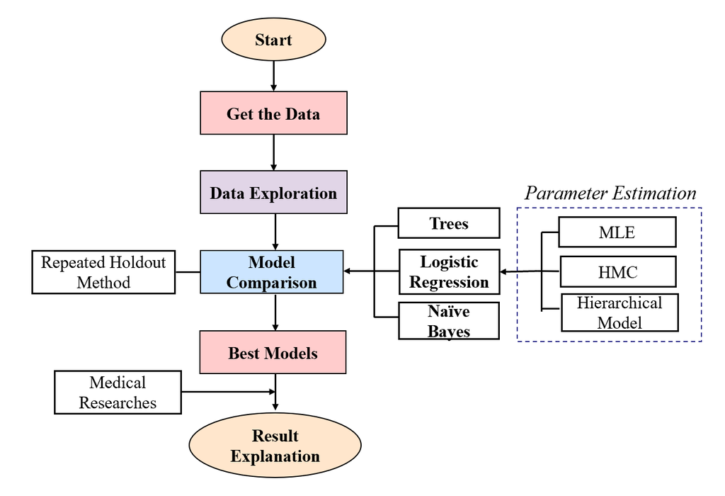

Flowchart of Proposed Study

# 2 Data Description

We apply our study on the data from the Breast Cancer Coimbra dataset from the UCI machine learning repository. There are accurate 116 instances in this dataset.There are nine predictive variables and a binary dependent variable(‘Classification’) that suggest the occurrence or absence of breast cancer. The predictive variables are anthropometric data and parameters, which can be obtained by routine blood sampling. All predictive variables are quantitative variables as the table shows.

| Predictive Variable | Definition | Units |
| --- | --- | --- |
| Age | The length of time that a person has lived. | $years$ |
| BMI | A numerical value calculated using a person’s weight and height. | $kg/m^2$ |
| Glucose | A simple sugar that serves as the primary source of energy in the body. | $mg/dL$ |
| Insulin | A hormone produced by the pancreas that helps regulate blood sugar levels. | $μU/dL$ |
| HOMA | A hormone produced by the pancreas that helps regulate blood sugar levels | / |
| Leptin | A hormone produced by fat cells that regulates appetite and energy expenditure. | $ng/dL$ |
| Adiponectin | A hormone secreted by adipose tissue (fat cells) that helps regulate glucose levels and fatty acid breakdown. | $μg/dL$ |
| Resistin | A hormone secreted by adipose tissue that may play a role in insulin resistance and inflammation. | $ng/dL$ |
| MCP.1 | A chemokine protein involved in immune responses. | $pg/dL$ |

The first five rows of the data are as follows:

```r
#load data
df <- read.csv('dataR2.csv')
# Convert qualitative variables to factors
qual_vars <- c("Classification")  # Response variable names
df[qual_vars] <- lapply(df[qual_vars], as.factor)
head(df, 5) %>%
  DT::datatable()
```

|  | Age | BMI | Glucose | Insulin | HOMA | Leptin | Adiponectin | Resistin | MCP.1 | Classification |
| --- | --- | --- | --- | --- | --- | --- | --- | --- | --- | --- |
| 1 | 48 | 23.5 | 70 | 2.707 | 0.467408667 | 8.807 | 9.7024 | 7.99585 | 407.004 | 0 |
| 2 | 83 | 20.69049454 | 92 | 3.005 | 0.706897333 | 8.8438 | 5.429285 | 4.06405 | 468.786 | 0 |
| 3 | 82 | 23.02467037 | 90 | 4.498 | 0.009650067 | 7.9393 | 22.43204 | 9.27705 | 554.697 | 0 |
| 4 | 68 | 20.36752037 | 77 | 3.226 | 0.602724933 | 9.8827 | 7.06956 | 2.766 | 928.22 | 0 |
| 5 | 86 | 20 | 92 | 3.549 | 0.8053864 | 6.6994 | 4.80924 | 0.57635 | 773.92 | 0 |

# 3 Methods Used in the Study

## 3.1 Logistic Regression model

In the field of medicine and clinical diagnosis, logistic regression models have always played an irreplaceable role and are the preferred choice for constructing many bio-medical models. In this paper, we still use the logistic regression model for breast cancer diagnosis.

We first fit a linear model using the frequentist method and then propose an alternative approach for parameter estimation using HMC (Hamiltonian Monte Carlo) algorithm. We use HMC algorithm instead of MH (Metropolis-Hastings) because of computational limitations. With randomly generated proposals, MH often takes a large number of iterations to get into areas of higher posterior density and HMC emerges as a preferred alternative for Bayesian analysis to improve efficiency and reduce the cost of time. We also apply a hierarchical method to estimate the parameters of the logistic regression model. Hierarchical models possess the advantage of fine-grained parameter estimation and layering, thereby enablng them with enhanced flexibility in capturing the underlying patterns in the data.

For binary response, we let

$$p = Pr(\mathbf{y} = 1 | \mathbf{X}) =
[1 + e^{-\mathbf{X}\boldsymbol\beta}]^{-1}.$$

The vector of responses is $\mathbf{y} = (y_1, ..., y_n)^T$. The covariate values for subject $i$ are $\mathbf{x}_i^T = (x_{i0}, ..., x_{iq})$ for $q$ predictive variables plus an intercept. We write the full design matrix as $\mathbf{X} = (\mathbf{x}_1^T, ..., \mathbf{x}_n^T)^T \in \mathbb{R}^{n\times(q+1)}$ for $n$ observations. The regression coefficients are a vector of length $q + 1$, $\boldsymbol\beta = (\beta_0, ..., \beta_q)^T$.

### 3.1.1 HMC-Logistic Regression model

HMC (Hamiltonian Monte Carlo) is a Markov chain Monte Carlo (MCMC) algorithm used for sampling from complex probability distributions. It combines ideas from Hamiltonian dynamics and Metropolis-Hastings sampling to generate more efficient and effective samples. Hamiltonian dynamics is a concept borrowed from physics, specifically from Hamiltonian mechanics. It involves the use of a “Hamiltonian” function that characterizes the total energy of a system. In the context of HMC, this Hamiltonian function is applied to the parameters being sampled in Bayesian inference.In the hmc_learn package of R language, the leapfrog function is a key component for implementing Hamiltonian dynamics.

In the context of logistic regression with binary response, the HMC algorithm can be used to estimate the regression coefficients $\boldsymbol \beta$. The goal is to find the posterior distribution of $\boldsymbol \beta$ given the data $\boldsymbol X$and $\boldsymbol y$.

#### 3.1.1.1 Derive log posterior and gradient for HMC

In the hmc_learn package of R language, the leapfrog function is a key component for implementing Hamiltonian dynamics and it requires the gradient of the log posterior to simulate the Hamiltonian dynamics accurately.

First develop the likelihood and log likelihood,

$$\begin{aligned} f(\mathbf{y} |
\mathbf{X},\boldsymbol\beta) &= \prod_{i=1}^n p^{y_i} (1-p)^{1-y_i},
\\ &= \prod_{i=1}^{n}
\left(\frac{1}{1+e^{-\mathbf{x}_i^T\boldsymbol\beta}}\right)^{y_i}
\left(\frac{e^{-\mathbf{x}_i^T\boldsymbol\beta}}{1+e^{-\mathbf{x}_i^T\boldsymbol\beta}}\right)^{1-y_i},
\\ \log f(\mathbf{y} | \mathbf{X}, \boldsymbol\beta) &= \sum_{i=1}^n
-y_i\log(1+e^{-\mathbf{x}_i^T\boldsymbol\beta}) +
(1-y_i)(-\mathbf{x}_i\boldsymbol\beta -
\log(1+e^{-\mathbf{x}_i^T\boldsymbol\beta})), \\ &= \sum_{i=1}^n
-\log(1+e^{-\mathbf{x}_i\boldsymbol\beta}) -
\mathbf{x}_i^T\boldsymbol\beta(1 - y_i), \\ &= \sum_{i=1}^n
\mathbf{x}_i^T\boldsymbol\beta(y_i - 1) - \log(1 +
e^{-\mathbf{x}_i^T\boldsymbol\beta}), \\ &=
\boldsymbol\beta^T\mathbf{X}^T(\mathbf{y} - \mathbf{1}_n) -
\mathbf{1}_n^T [ \log( 1 + e^{-\mathbf{X}\boldsymbol\beta})].
\end{aligned}$$
Then set a multivariate normal prior for $\boldsymbol\beta$

$$\begin{aligned} \boldsymbol\beta
&\sim N(0, \sigma_\beta^2 \mathbf{I}), \end{aligned}$$

with pdf, omitting constants

$$\begin{aligned} \pi(\boldsymbol\beta |
\sigma_\beta^2) &= \frac{1}{\sqrt{\lvert 2\pi \sigma_\beta^2 \rvert
}}e^{-\frac{1}{2}\boldsymbol\beta^T \boldsymbol\beta / \sigma_\beta^2},
\\ \log \pi(\boldsymbol\beta | \sigma_\beta^2) &=
-\frac{1}{2}\log(2\pi \sigma_\beta^2) - \frac{1}{2}\boldsymbol\beta^T
\boldsymbol\beta / \sigma_\beta^2, \\ &\propto -\frac{1}{2}\log
\sigma_\beta^2 -
\frac{\boldsymbol\beta^T\boldsymbol\beta}{2\sigma_\beta^2}.
\end{aligned}$$

Next, we derive the log posterior, omitting constants,

$$\begin{aligned} f(\boldsymbol\beta |
\mathbf{X}, \mathbf{y}, \sigma_\beta^2) &\propto f(\mathbf{y} |
\mathbf{X}, \boldsymbol\beta) \pi(\boldsymbol\beta | \sigma_\beta^2), \\
\log f(\boldsymbol\beta | \mathbf{X}, \mathbf{y}, \sigma_\beta^2) &
\propto \log f(\mathbf{y} | \mathbf{X}, \boldsymbol\beta) + \log
\pi(\boldsymbol\beta|\sigma_\beta^2), \\ &\propto \sum_{i=1}^n
\mathbf{x}_i^T\boldsymbol\beta(y_i - 1) - \log(1 +
e^{-\mathbf{x}_i^T\boldsymbol\beta}) -
\frac{1}{2}\boldsymbol\beta^T\boldsymbol\beta / \sigma_\beta^2, \\
&\propto \boldsymbol\beta^T\mathbf{X}^T(\mathbf{y} - \mathbf{1}_n) -
\mathbf{1}_n^T[\log( 1 + e^{-\mathbf{X}\boldsymbol\beta})] -
\frac{\boldsymbol\beta^T\boldsymbol\beta}{2\sigma_\beta^2}.
\end{aligned}$$

Then, we need to derive the gradient of the log posterior for the leapfrog function

$$\begin{aligned}
\nabla_{\boldsymbol\beta} \log f(\boldsymbol\beta, \mathbf{X},
\mathbf{y}, \sigma_\beta^2) &\propto \mathbf{X}^T \left ( \mathbf{y}
- \mathbf{1}_n+ \frac{e^{-\mathbf{X}\boldsymbol\beta}}{1 +
e^{-\mathbf{X}\boldsymbol\beta}}\right) - \boldsymbol\beta /
\sigma_\beta^2 \end{aligned}$$

This gradient is used within the leapfrog function of the HMC algorithm to simulate the Hamiltonian dynamics of the system. By integrating these dynamics, HMC generates proposals for $\boldsymbol \beta$ that are accepted or rejected based on the Metropolis-Hastings acceptance criterion.

The following flowchart shows the key steps in HMC. Initial values for $\boldsymbol \theta$ and $\boldsymbol p$ are required to start the algorithm. With $\boldsymbol \theta^{(0)}$ and $\boldsymbol p^{(0)}$ specified, the leapfrog algorithm is used to find approximate solutions to the Hamiltonian equations. The leapfrog solutions define the path of $(\boldsymbol \theta,\boldsymbol p)$ over time within an iteration.

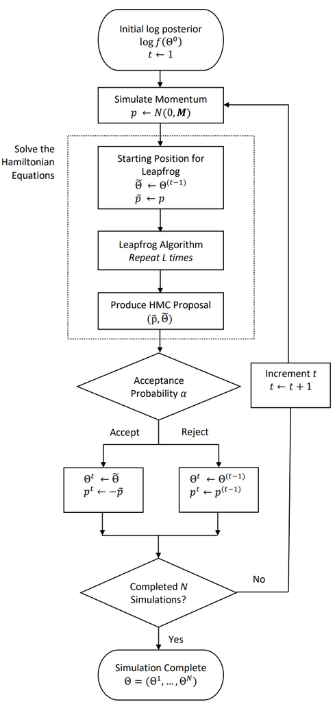

Main Steps of the Hamiltonian Monte Carlo Method

### 3.1.2 Frequentist-Logistic Regression model

Frequentist logistic regression is a statistical method commonly used for binary classification problems. It aims to estimate the parameters of a logistic regression model based on the maximum likelihood principle.

#### 3.1.2.1 Maximum Likelihood Estimation

The goal of frequentist logistic regression is to find the estimates of the parameter vector $\boldsymbol \beta$ that maximize the likelihood function. The likelihood function is formulated as follows:

$$L(\boldsymbol{\beta}) = \prod_{i=1}^{n} p^{y_i}(1-p)^{1-y_i}$$

Here, $y_i$ represents the observed response value for the (i)th observation, and (n) is the total number of observations.

Taking the logarithm of the likelihood function, we obtain the log-likelihood function:

$$\log L(\boldsymbol{\beta}) = \sum_{i=1}^{n} y_i\log(p) +
(1-y_i)\log(1-p)$$

#### 3.1.2.2 Estimate Parameters

To estimate the parameters $\boldsymbol{\beta}$, we use an optimization algorithm such as gradient descent or Newton-Raphson. The algorithm iteratively updates the parameter estimates to maximize the log-likelihood function.

The gradient of the log-likelihood function with respect to the parameter vector $\boldsymbol{\beta}$ is given by:

$$\nabla_{\boldsymbol{\beta}} \log
L(\boldsymbol{\beta}) = \sum_{i=1}^{n} (y_i - p)x_i$$

The iterative optimization algorithm adjusts the parameter estimates based on this gradient until convergence.

## 3.2 Naive Bayes

Bayesian classification is a type of non-parametric classification that induces a classifier from a training set and uses the classifier to classify unlabeled data. It includes Naive Bayes algorithm, Bayesian network classifiers and others. The characteristics of Bayesian classification are as follows:

1. Bayesian classification calculates the probability of belonging to a certain class and assigns the class with the highest probability to the instance.
2. All attributes, either directly or indirectly, contribute to the classification.
3. The attributes of Bayesian classification instances can be discrete, continuous or mixed.

Let $A_1, A_2, \dots, A_n$ be the n features of a dataset, with a total of m classes denoted by C = ${C_1, C_2, \dots, C_m}$. Given a specific instance X with attributes $x_1, x_2, \dots, x_n$, where $x_i$ is a specific value belonging to $A_i$, the posterior probability of instance X belonging to class $C_i$ is denoted as $P(X|C_i)$, and $c(X)$ represents the assigned class label. The Bayesian classifier can be expressed as:

$$\begin{aligned}
&c(X)=\underset{C_i \in C}{\arg \max } P\left(C_i\right) P\left(X
\mid C_i\right)\\
\end{aligned}$$
The formula (*) predicts the class label of instance X by maximizing the posterior probability under the given attribute conditions, thus achieving the highest prediction accuracy.

In practice, computing the posterior probability in formula () is challenging. Therefore, the Naive Bayes algorithm introduces the following assumption:

Under the given class C, all attributes $A_i$ are mutually independent. That is:

$$\begin{aligned}
&P\left(A_i \mid C, A_j\right)=P\left(A_i \mid C\right), \forall A
i, A j, P(C)>0
\end{aligned}$$

The Naive Bayes algorithm represented by a Bayesian network is shown in the figure .

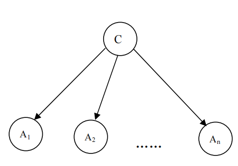

Bayesian Network

In the Naive Bayes algorithm, we can independently learn the conditional probability $P(A_i|C)$ of each attribute $A_i$ under the class attribute C, or we can independently learn the probability of each attribute $A_i$, which is a constant value that can be replaced by a normalization factor, denoted as $\alpha$. Then, the classifier applies Bayes’ formula to calculate the posterior probability of a specific instance’s data given the attribute values for a particular class:
$$\begin{aligned}
P\left(C=c \mid A_1=a_1 \ldots A_n=a_n\right)=\alpha P(C=c)
\prod_{i=1}^n P\left(A_i \mid C=c\right)
\end{aligned}$$

Finally, the classifier predicts the class of the instance based on the class with the maximum posterior probability.

The Naive Bayes classifier is widely used due to its efficient computation, high accuracy, and solid theoretical foundation. Therefore, we choose this model.

## 3.3 Decision Trees

Decision tree is a modern machine learning method that is suitable for various tasks such as regression and classification based on tabular data. The decision tree model can be represented as a general expression involving indicator function compositions. The algorithm’s main working principle is space search and space partitioning, which makes it robust and not highly dependent on data types and data completeness. Therefore, it is widely used as a popular machine learning method. Here is the general expression for a decision tree model:
$$f(\mathbf{x}) = \sum*{i=1}^{N} w_i* \cdot \prod{j=1}^{M} [x_j \in
R_{ij}]$$
In the above expression, $\mathbf{x}$ represents the input feature vector, $N$ represents the total number of decision tree nodes, $M$ represents the number of features, $w_i$ represents the weight associated with the $i$-th leaf node, and $R_{ij}$ represents the $j$-th region defined by the $i$-th node in the decision tree. A decision tree is a popular machine learning method that is used for tasks such as regression and classification based on tabular data.

The basic principle behind a decision tree model is to recursively partition the feature space into regions based on the values of the input features, ultimately resulting in a tree-like structure. At each internal node of the tree, a decision is made based on a specific feature and its corresponding threshold value. This decision splits the data into two or more subsets, which are then passed down to the child nodes. This process continues until a termination criterion is met, such as reaching a maximum depth or a minimum number of samples in a leaf node.

In a classification scenario, each leaf node represents a class label, and the decision path from the root node to a particular leaf node determines the predicted class for an input sample. In a regression scenario, the leaf nodes contain predicted continuous values instead of class labels.

The construction of a decision tree involves determining the optimal splits at each internal node based on certain criteria, such as maximizing information gain or minimizing impurity. These criteria measure the homogeneity or purity of the data subsets after the split. Different algorithms, such as CART (Classification and Regression Trees) or ID3 (Iterative Dichotomiser 3), use different criteria and heuristics to construct decision trees. Decision trees have several advantages, including their interpretability and ability to handle both categorical and numerical features. They can handle missing values and are less sensitive to outliers. However, decision trees are prone to overfitting, especially when the tree becomes too deep or when the dataset is noisy. Various techniques, such as pruning, regularization, or ensemble methods like random forests, can be employed to mitigate overfitting and improve generalization performance.

For this data set, we mainly use DT algorithm as a representative machine learning model to compare the predictive effect of our bayesian method with generally used machine learning method. We primarily utilized the CART algorithm to construct the decision tree model. In order to ensure fairness, we set all the initial hyperparameters of the decision tree to their default values to avoid any subjective factors influencing the comparative results. Additionally, we recognized that there could be occasional results due to randomness when using different training and testing sets. To address this issue, we performed repeated holdout operations. This involved dividing the entire dataset into training and testing sets 20 times by setting different random seeds. For each partition, we trained the model on the training set and evaluated the model’s predictions and relevant metrics on the testing set. Finally, we calculated the average of these metrics to obtain the most objective and fair evaluation results possible.

# 4 Data Exploration

By examining the data, we can observe that the data structure consists of 116 rows and 10 columns, with 9 predictive variables as the predictor variables and the response variable as a categorical variable. Furthermore, there are no missing values in the dataset, thus no imputation is required. In this case, the attributes with the lowest standard deviation (SD) are HOMA, BMI and Adiponectin respectively.

```r
glimpse(df)
```

[output not shown]

```r
#The mean, variance, quantiles, and missing values of the predictive variables.
skim(df)
```

Data summary

| Name | df |
| --- | --- |
| Number of rows | 116 |
| Number of columns | 10 |
| _______________________ |  |
| Column type frequency: |  |
| factor | 1 |
| numeric | 9 |
| ________________________ |  |
| Group variables | None |

**Variable type: factor**

| skim_variable | n_missing | complete_rate | ordered | n_unique | top_counts |
| --- | --- | --- | --- | --- | --- |
| Classification | 0 | 1 | FALSE | 2 | 1: 64, 0: 52 |

**Variable type: numeric**

| skim_variable | n_missing | complete_rate | mean | sd | p0 | p25 | p50 | p75 | p100 | hist |
| --- | --- | --- | --- | --- | --- | --- | --- | --- | --- | --- |
| Age | 0 | 1 | 57.22 | 16.10 | 24.00 | 45.00 | 56.00 | 70.00 | 89.00 | ▂▇▃▇▂ |
| BMI | 0 | 1 | 27.08 | 5.91 | 8.37 | 22.97 | 27.66 | 30.52 | 38.58 | ▁▁▅▇▂ |
| Glucose | 0 | 1 | 65.22 | 38.94 | 0.00 | 30.00 | 84.00 | 92.00 | 200.00 | ▅▂▇▁▁ |
| Insulin | 0 | 1 | 8.06 | 9.98 | 0.07 | 3.50 | 5.07 | 6.82 | 58.46 | ▇▁▁▁▁ |
| HOMA | 0 | 1 | 2.15 | 3.47 | 0.00 | 0.43 | 0.79 | 2.86 | 25.05 | ▇▁▁▁▁ |
| Leptin | 0 | 1 | 23.47 | 21.46 | 0.06 | 6.73 | 20.15 | 37.38 | 90.28 | ▇▅▃▁▁ |
| Adiponectin | 0 | 1 | 7.67 | 7.22 | 0.01 | 3.70 | 6.24 | 8.41 | 38.04 | ▇▃▁▁▁ |
| Resistin | 0 | 1 | 11.11 | 13.55 | 0.06 | 4.08 | 6.46 | 9.50 | 82.00 | ▇▂▁▁▁ |
| MCP.1 | 0 | 1 | 448.20 | 251.65 | 2.00 | 255.11 | 407.10 | 642.65 | 994.31 | ▃▇▅▅▂ |

The histogram of the response variable demonstrates that there is no issue of data imbalance present in the dataset.

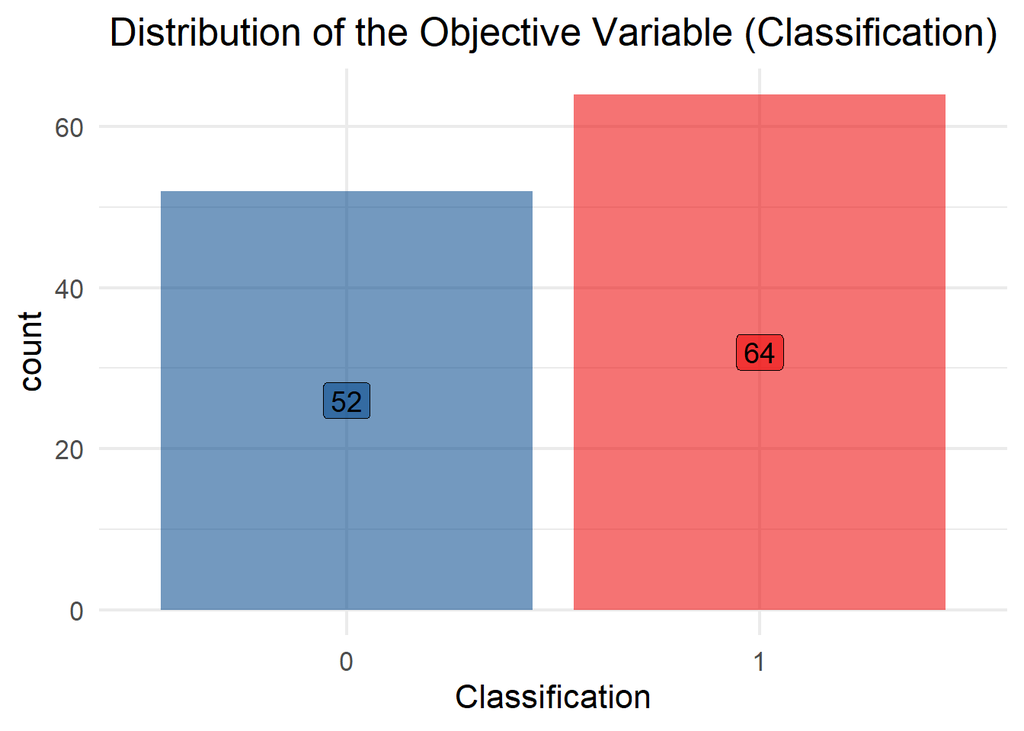

```r
p1 <- ggplot(df, aes(x = Classification, fill = Classification, alpha = 0.7)) +
  geom_bar(stat = "count", position = "stack", show.legend = FALSE) +
  scale_color_lancet() + scale_fill_lancet() +
  theme_minimal(base_size = 16) +
  geom_label(stat = "count", aes(label = ..count..), position = position_stack(vjust = 0.5),
             size = 5, show.legend = FALSE) +
  labs(title = "Distribution of the Objective Variable (Classification)") +
  theme(plot.title = element_text(hjust = 0.5))

p1
```

From the distribution plots of the predictive variables, we can observe that there are significant differences in the distributions of most variables when considering different predictive variables.

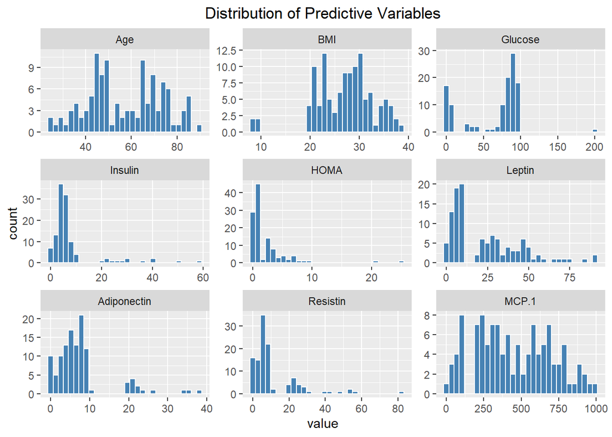

```r
df_long <- reshape2::melt(df[,-10])
ggplot(data = df_long, aes(x = value)) +
  geom_histogram(fill = "steelblue", color = "white") +
  facet_wrap(~ variable, scales = "free") +
  labs(title = "Distribution of Predictive Variables")+
  theme(plot.title = element_text(hjust = 0.5))
```

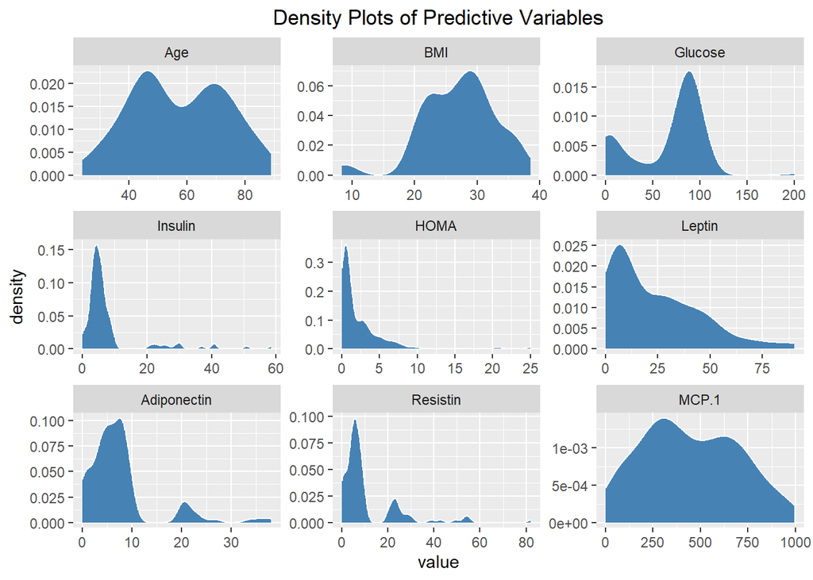

```r
ggplot(data = df_long, aes(x = value)) +
  geom_density(fill = "steelblue", color = "white") +
  facet_wrap(~ variable, scales = "free") +
  labs(title = "Density Plots of Predictive Variables") +
  theme(plot.title = element_text(hjust = 0.5))
```

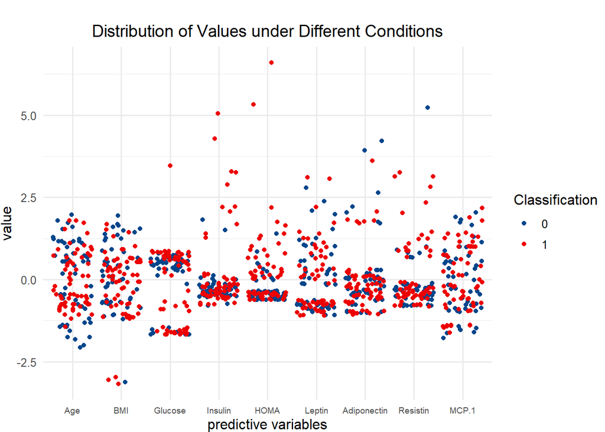

```r
p1 <- ggplot(df_t_m,
       aes(factor(features,
                  levels = c("Age", "BMI", "Glucose", "Insulin", "HOMA",
                             "Leptin", "Adiponectin", "Resistin", "MCP.1")),
           value, fill = Classification)) +
  geom_jitter(aes(colour = Classification)) +
  scale_color_lancet()+scale_fill_lancet()+
  labs(x = "predictive variables", y = "value") +
  theme_minimal(base_size = 12) +
  theme(axis.text.x = element_text(size = 7),
        plot.title = element_text(hjust = 0.5, size = 14)) +
  ggtitle("Distribution of Values under Different Conditions") +
  theme(plot.margin = margin(t = 20))

p1
```

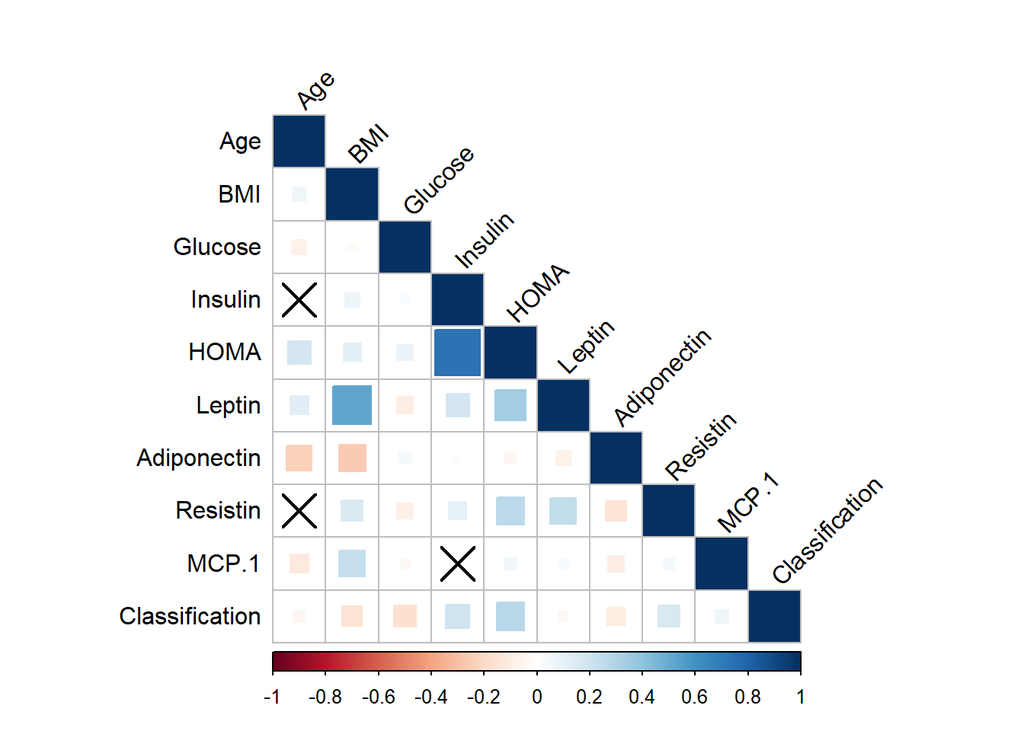

# 5 Main Results

The prediction effects of the models are compared upon both the simulation dataset and the real dataset. Also, the simulation dataset enables us to further compare the estimation of coefficients using the three different methods in the logistic regression model.

Firstly, we generate a vector of length $100 \times 9$ from a standard normal distribution. This vector is then reshaped into a matrix with $100$ rows and $9$ columns, resulting in $9$ independent predictive variables that fulfill the requirements for using the naive Bayes method.

Finally, the response variable $y$ is generated using the function `rbinom` with $n=1$, along with the randomly generated probabilities obtained previously.

Firstly, the simulation dataset and the real dataset are devided into training and validation sets by a 3:1 ratio. The training set for the simulation dataset consists of 75 samples, while the training set for the real dataset contains 87 samples. Since our prediction problem is a binary classification task and there is no imbalance issue in the dataset, we select three metrics to better evaluate the model’s performance on the dataset: the cost of time from generating the model to produce probabilities, the prediction accuracy, and AUC. The formulas for calculating accuracy and AUC are as follows:

$$\text { Accuracy }=\frac{T P+T N}{T P+T N+F P+F N}$$

$$\text {AUC} =\frac{\sum \boldsymbol{I}\left(\boldsymbol{P}_{\text
{positive }}, \boldsymbol{P}_{\text {negative }}\right)}{M * N}$$

Next, we fit the Naive Bayes model, logistic regression models, and the decision trees model on the training set and make predictions on the validation set, comparing the performance of the models. To increase statistical significance, we conduct the repeated holdout method by 20 times. In order to ensure consistency between the training and validation sets for different models, we set the random seed to be 1-20 for iteration.

## 5.1 Simulation Study

### 5.1.1 Logistic Regression

#### 5.1.1.1 HMC-Logistic Regression

```r
logistic_posterior <- function(theta, y, X, sig2beta=1e8) {
k <- length(theta)
beta_param <- as.numeric(theta)
onev <- rep(1, length(y))
ll_bin <- t(beta_param) %*% t(X) %*% (y - 1) -
t(onev) %*% log(1 + exp(-X %*% beta_param))
result <- ll_bin - 1/2* t(beta_param) %*%
beta_param / sig2beta
return(result)
}

g_logistic_posterior <- function(theta, y, X, sig2beta=1e8) {
n <- length(y)
k <- length(theta)
beta_param <- as.numeric(theta)
result <- t(X) %*% ( y - 1 + exp(-X %*% beta_param) /
(1 + exp(-X %*% beta_param))) -beta_param/sig2beta
return(result)
}

hmc_logistic_s <- function(Train,Test){
  t1.lg <- Sys.time()
  stand_range <- preProcess(Train[,-10])
  Train_scaled <- cbind(predict(stand_range ,Train[,-10]),Train[,10])
  Test_scaled <- cbind(predict(stand_range ,Test[,-10]), Test[,10])

  X_train <- model.matrix(Classification ~  Age + BMI + Glucose + Insulin +
                            HOMA + Leptin + Adiponectin + Resistin + MCP.1-1,
                  data =  Train_scaled)
  X_train <- cbind(1,X_train)

  y_train <- Train$Classification


  N <- 10000
  continuous_ind <- c(rep(TRUE, 10))
  eps_vals <- ifelse(continuous_ind, 0.1, 1e-3)
  fm2_hmc <- hmc(N, theta.init = rep(1, 10),
               epsilon = eps_vals, L = 20,
               logPOSTERIOR = logistic_posterior,
               glogPOSTERIOR = g_logistic_posterior,
               param = list(y = y_train, X = X_train),
               varnames = colnames(X_train),
               chains = 2, parallel = FALSE)
  result <- summary(fm2_hmc, burnin=2000)

  param1 <- result[,4][1]
  param2 <- result[,4][2]
  param3 <- result[,4][3]
  param4 <- result[,4][4]
  param5 <- result[,4][5]
  param6 <- result[,4][6]
  param7 <- result[,4][7]
  param8 <- result[,4][8]
  param9 <- result[,4][9]
  param10 <- result[,4][10]

  sigmoid <- function(x) {
    1 / (1 + exp(-x))
  }

  data1 <- as.data.frame(Test_scaled)

  linear_pred <- param1  + param2 * data1$Age + param3 * data1$BMI + param4 * data1$Glucose +
  param5 * data1$Insulin + param6 * data1$HOMA + param7 * data1$Leptin +
  param8 * data1$Adiponectin + param9 * data1$Resistin + param10 * data1$MCP.1

  probabilities <- sigmoid(linear_pred)

  t2.lg <- Sys.time()

  pred.class <- as.integer(probabilities > 0.5)
  cft <- table(pred.class, Test$Classification)
  accu <- (cft[1,1]+cft[2,2])/nrow(Test)

  time_cost <- t2.lg - t1.lg
  AUC <- roc(probabilities,response = Test$Classification)$auc
  acpt_rate <- sum(fm2_hmc$accept/N)/2


  t <- summary(fm2_hmc, burnin=3000, probs=c(0.025, 0.5, 0.975))
  for (i in t[,4]) {
    if (i >= 1.1){
      print('Convergence Problem')
    }
  }


  return(list(prob = probabilities,accuracy = accu,AUC = AUC,acceptance_rate = acpt_rate,time_cost = time_cost))
}

data1 <- read.csv('dataR2.csv')
data2 <- read.csv('Simulation.csv')
data2 <- data2[,2:11]
colnames(data2) <- colnames(data1)

accuracy_list <- list()
auc_list <- list()
time_list <- list()
acpt_rate_list <- list()
pred_prob_df <- data.frame(matrix(ncol = 0, nrow = 25))

for (i in c(1:20)) {
  set.seed(i)
  train <- sample(1:nrow(data2),nrow(data2)*3/4,replace = FALSE)
  Train <-  data2[train,]
  Test <- data2[-train,]

  results_sim <- hmc_logistic_s(Train,Test)

  accuracy_list[[i]] <- results_sim$accuracy
  auc_list[[i]] <-results_sim$AUC
  time_list[[i]] <- results_sim$time_cost
  acpt_rate_list[[i]] <- results_sim$acceptance_rate

  pred_prob_df <- cbind(pred_prob_df, results_sim$prob)
}

accuracy_df <- t(data.frame(accuracy = unlist(accuracy_list)))
rownames(accuracy_df) <- "hmc_accuracy"
colnames(accuracy_df) <- paste0("iteration_", 1:20)

auc_df <- t(data.frame(AUC = unlist(auc_list)))
rownames(auc_df) <- "hmc_AUC"
colnames(auc_df) <- paste0("iteration_", 1:20)

time_df <- t(data.frame(time = unlist(time_list)))
rownames(time_df) <- "hmc_time"
colnames(time_df) <- paste0("iteration_", 1:20)

acpt_rate_df <- t(data.frame(acpt_rate = unlist(acpt_rate_list)))
rownames(acpt_rate_df) <- "hmc_acpt_rate"
colnames(acpt_rate_df) <- paste0("iteration_", 1:20)

colnames(pred_prob_df) <- paste0("iteration_", 1:20)

write.csv(pred_prob_df,"simu_pred_prob_df.csv")
write.csv(acpt_rate_df,"simu_acpt_rate_df.csv")
write.csv(time_df,"simu_time_df.csv")
write.csv(auc_df,"simu_auc_df.csv")
write.csv(accuracy_df,"simu_accuracy_df.csv")
```

```r
data3 <- read.csv('Simulation.csv')
data3 <- data3[,2:11]
colnames(data3) <- c('X1','X2','X3','X4','X5','X6','X7','X8','X9','Classification')

  X_train <- model.matrix(Classification ~ .-1,
                  data = data3)
  X_train <- cbind(1,scale(X_train))
  y_train <- data3$Classification

  N <- 10000
  continuous_ind <- c(rep(TRUE, 10))
  eps_vals <- ifelse(continuous_ind, 0.1, 1e-3)
  fm2_hmc <- hmc(N, theta.init = rep(1, 10),
               epsilon = eps_vals, L = 20,
               logPOSTERIOR = logistic_posterior,
               glogPOSTERIOR = g_logistic_posterior,
               param = list(y = y_train, X = X_train),
               varnames = colnames(X_train),
               chains = 2, parallel = FALSE)
  result <- summary(fm2_hmc, burnin=2000)


  t <- summary(fm2_hmc, burnin=3000, probs=c(0.025, 0.5, 0.975))
  for (i in t[,4]) {
    if (i >= 1.1){
      print('Convergence Problem')
    }
  }
```

#### 5.1.1.2 Frequentist-Logistic Regression

```r
frequentist_logistic <- function(Train,Test){
  t1.lg <- Sys.time()

  stand_range <- preProcess(Train[,-10])
  Train_scaled <- cbind(predict(stand_range ,Train[,-10]),Train[,10])
  Test_scaled <- cbind(predict(stand_range ,Test[,-10]), Test[,10])

  colnames(Train_scaled) <- c("Age","BMI","Glucose","Insulin","HOMA" ,"Leptin","Adiponectin","Resistin","MCP.1",'Classification')

  colnames(Test_scaled) <- c("Age","BMI","Glucose","Insulin","HOMA" ,"Leptin","Adiponectin","Resistin","MCP.1",'Classification')

  X_train <- model.matrix(Classification ~  Age + BMI + Glucose + Insulin +
                            HOMA + Leptin + Adiponectin + Resistin + MCP.1-1,
                  data =  Train_scaled)
  X_train <- cbind(1,X_train)

  y_train <- Train$Classification

  colnames(X_train) <- c("Intercept","Age","BMI","Glucose","Insulin","HOMA" ,"Leptin","Adiponectin", "Resistin","MCP.1")

  freq_model <- glm(y_train ~ Age + BMI + Glucose + Insulin +
           HOMA + Leptin + Adiponectin + Resistin +
           MCP.1-Intercept, family = binomial(),data = as.data.frame(X_train))


  X_test <- model.matrix(Classification ~  Age + BMI + Glucose + Insulin +
                            HOMA + Leptin + Adiponectin + Resistin + MCP.1-1,
                  data = Test_scaled)
  X_test <- cbind(1,X_test)
  X_test <- as.data.frame(X_test,row.names = c(1:29))

  colnames(X_test) <- c("Intercept","Age","BMI","Glucose","Insulin","HOMA" ,"Leptin","Adiponectin","Resistin","MCP.1")

  probabilities <- predict(freq_model, X_test, type="response")

  t2.lg <- Sys.time()

  pred.class <- as.integer(probabilities > 0.5)
  cft <- table(pred.class, Test$Classification)
  accu <- (cft[1,1]+cft[2,2])/nrow(Test)
  time_cost <- t2.lg - t1.lg
  AUC <- roc(probabilities,response = Test$Classification)$auc


  return(list(prob = probabilities,accuracy = accu,AUC = AUC,time_cost = time_cost))
}

data1 <- read.xlsx('dataR2.xlsx')
data2 <- read.csv('Simulation.csv')
data2 <- data2[,2:11]
colnames(data2) <- colnames(data1)


accuracy_list <- list()
auc_list <- list()
time_list <- list()
# acpt_rate_list <- list()
pred_prob_df <- data.frame(matrix(ncol = 0, nrow = 25))

for (i in c(1:20)) {
  set.seed(i)
  train <- sample(1:nrow(data2),nrow(data2)*3/4,replace = FALSE)
  Train <-  data2[train,]
  Test <- data2[-train,]

  results_sim <- frequentist_logistic(Train,Test)

  accuracy_list[[i]] <- results_sim$accuracy
  auc_list[[i]] <-results_sim$AUC
  time_list[[i]] <- results_sim$time_cost
  # acpt_rate_list[[i]] <- results_sim$acceptance_rate

  pred_prob_df <- cbind(pred_prob_df, results_sim$prob)
}

accuracy_df <- t(data.frame(accuracy = unlist(accuracy_list)))
rownames(accuracy_df) <- "freq_accuracy"
colnames(accuracy_df) <- paste0("iteration_", 1:20)

auc_df <- t(data.frame(AUC = unlist(auc_list)))
rownames(auc_df) <- "freq_AUC"
colnames(auc_df) <- paste0("iteration_", 1:20)

time_df <- t(data.frame(time = unlist(time_list)))
rownames(time_df) <- "freq_time"
colnames(time_df) <- paste0("iteration_", 1:20)

colnames(pred_prob_df) <- paste0("iteration_", 1:20)

write.csv(pred_prob_df,"f_simu_pred_prob_df.csv")
write.csv(time_df,"f_simu_time_df.csv")
write.csv(auc_df,"f_simu_auc_df.csv")
write.csv(accuracy_df,"f_simu_accuracy_df.csv")


data4 <- read.csv('Simulation.csv')
data4 <- data4[,2:11]
colnames(data4) <- c('X1','X2','X3','X4','X5','X6','X7','X8','X9','Classification')

X_train <- model.matrix(Classification ~ .-1,
                  data = data4)
  X_train <- cbind(1,scale(X_train))
  y_train <- data4$Classification
  colnames(X_train) <- c("Intercept","Age","BMI","Glucose","Insulin","HOMA" ,"Leptin","Adiponectin", "Resistin","MCP.1")

  freq_model <- glm(y_train ~ Age + BMI + Glucose + Insulin +
           HOMA + Leptin + Adiponectin + Resistin +
           MCP.1-1, family = binomial(),data = as.data.frame(X_train))
  summary(freq_model,probs=c(0.025, 0.5, 0.975))
```

```
Call:
glm(formula = y_train ~ Age + BMI + Glucose + Insulin + HOMA +
    Leptin + Adiponectin + Resistin + MCP.1 - 1, family = binomial(),
    data = as.data.frame(X_train))

Deviance Residuals:
     Min        1Q    Median        3Q       Max
-1.81279  -0.50523   0.04689   0.80822   2.14238

Coefficients:
            Estimate Std. Error z value Pr(>|z|)
Age           1.7411     0.4522   3.851 0.000118 ***
BMI           0.7715     0.3285   2.349 0.018844 *
Glucose       1.1508     0.3549   3.243 0.001183 **
Insulin       0.6606     0.3046   2.169 0.030079 *
HOMA          1.5189     0.4339   3.500 0.000465 ***
Leptin        0.6396     0.3147   2.032 0.042137 *
Adiponectin   1.0555     0.3523   2.996 0.002735 **
Resistin      0.9803     0.3428   2.860 0.004235 **
MCP.1         1.2334     0.3856   3.198 0.001382 **
---
Signif. codes:  0 '***' 0.001 '**' 0.01 '*' 0.05 '.' 0.1 ' ' 1

(Dispersion parameter for binomial family taken to be 1)

    Null deviance: 138.629  on 100  degrees of freedom
Residual deviance:  77.965  on  91  degrees of freedom
AIC: 95.965

Number of Fisher Scoring iterations: 6
```

#### 5.1.1.3 Hierarchical Logistic Regression

```r
hierarchical_model <- function(Train,Test){
  stand_range <- preProcess(Train[,-10])
  Train_scaled <- cbind(predict(stand_range ,Train[,-10]),Train[,10])
  Test_scaled <- cbind(predict(stand_range ,Test[,-10]), Test[,10])
  t1 <- Sys.time()
  # model string
  jags.model = textConnection("model{
    for( i in 1:N) {
        xcent[i,1:9] <- x[i,1:9] - mean(x[,1:9])
    }
    for(i in 1:N){
        # likelihood:  y[i] ~ Bernoulli(p[i])
        y[i] ~ dbern(p[i])
        # the logit of p[i] is a linear function of the
        # centered log dose x[i]
        logit(p[i]) <- alpha.star + sum(xcent[i,] * beta) # Centered the covariate
    }
    alpha <- alpha.star - sum(t(mean(x[,1:9])) * beta)
    for(i in 1:9){
        beta[i] ~ dnorm(mu.beta, tau.beta)
    }

    alpha.star ~ dnorm(mu.alpha, tau.alpha)
    mu.beta ~ dnorm(0,0.000001)
    sigma.beta ~ dunif(1,10)
    tau.beta <- 1/(sigma.beta*sigma.beta)
    mu.alpha ~ dnorm(0,0.000001)
    sigma.alpha ~ dunif(20,30)
    tau.alpha <- 1/(sigma.alpha*sigma.alpha)
}")

  # train and MCMC

  data3 <- list(
    x = as.matrix(Train_scaled)[,-10],
    n = rep(1,75),
    y = as.vector(Train_scaled[,10]),
    N = 75)

  inits1 <- list(alpha.star=0, beta=rep(0.1, 9),mu.beta=0,mu.alpha=0,sigma.alpha=23,sigma.beta=3)
  inits2 <- list(alpha.star=0, beta=rep(-0.1, 9),mu.beta=0,mu.alpha=0,sigma.alpha=25,sigma.beta=5)
  inits3 <- list(alpha.star=0, beta=rep(0.7, 9),mu.beta=0,mu.alpha=0,sigma.alpha=28,sigma.beta=7)
  inits <- list(inits1,inits2,inits3)

  j.model <- jags.model(file = jags.model,
                        data = data3,
                        inits = inits,
                        n.chains = 3) # Set 3 chains
  update(j.model, 1000) # 1000 Update
  params <- c("alpha", "beta")
  jags.out <- coda.samples(j.model, params, n.iter = 50000, n.burnin = 2000)
  t2 <- Sys.time()
  # Set 50000 iterations

  # Calculate the accuracy in test data set
  res_all <- summary(jags.out)
  para.estimate <- res_all[1]$statistics[1:10,1]
  dim(para.estimate) <- c(10,1)
  prob <- as.matrix(cbind(1,Test_scaled[,-10]))%*%para.estimate
  prob1 <- exp(prob)/(1+exp(prob))
  auc <- roc(as.numeric(Test_scaled[,10]), prob1)$auc
  accu <- 1-sum(abs(as.numeric(prob1>0.5)-Test_scaled[,10]))/dim(Test_scaled)[1]

  return(list(res=jags.out,time=(t2-t1),accu=accu,auc=auc,pred_prob=prob1))
}

# res=hierarchical_model(Train,Test)
time <- c()
auc <- c()
accu <- c()
pred_prob=c()

for(i in 1:20){
  set.seed(i)
  train <- sample(1:nrow(data4),nrow(data4)*3/4,replace = FALSE)
  Train <- data4[train,]
  Test <- data4[-train,]
  res = hierarchical_model(Train,Test)
  time <- c(time,res$time)
  auc <- c(auc,res$auc)
  accu <- c(accu,res$accu)
  pred_prob <- cbind(pred_prob,res$pred_prob)
}

write.csv(time,"time.csv")
write.csv(auc,"AUC.csv")
write.csv(accu,"Accuracy.csv")
write.csv(pred_prob,"Pred_prob_res.csv")
```

#### 5.1.1.4 Comparison of the estimation effects

```r
# HMC
hmc_data <- data.frame(
  Parameter = c("(Intercept)", "X1", "X2", "X3", "X4", "X5", "X6", "X7", "X8", "X9"),
  Estimate = c(0.6657143, 2.2124113, 1.0828732, 1.4895894, 0.7867817, 1.9797608, 0.8342914, 1.3053750, 1.3605785, 1.6804235),
  Q2.5 = c(0.04693995, 1.27424260, 0.38370859, 0.76878863, 0.16638055, 1.05167363, 0.15361816, 0.60937579, 0.61210360, 0.83311135),
  Q97.5 = c(1.368385, 3.432530, 1.951974, 2.374605, 1.496524, 3.159774, 1.596650, 2.180394, 2.235148, 2.753156)
)

hmc_data$Estimate <- round(hmc_data$Estimate, 2)
hmc_data$Q2.5 <- round(hmc_data$Q2.5, 2)
hmc_data$Q97.5 <- round(hmc_data$Q97.5, 2)


frequentist_data <- data.frame(
  Parameter = c("(Intercept)", "X1", "X2", "X3", "X4", "X5", "X6", "X7", "X8", "X9"),
  Estimate = c(0.5556, 1.8834, 0.9241, 1.2582, 0.6471, 1.6877, 0.7123, 1.1182, 1.1606, 1.4240),
  Q2.5 = c(0.43,1.69,0.78,1.11,0.53,1.5,0.58,0.98,1.01,1.26),
  Q97.5 = c(0.68,2.07,1.06,1.4,0.77,1.87,0.84,1.26,1.31,1.59))

frequentist_data$Estimate <- round(frequentist_data$Estimate, 2)
frequentist_data$Q2.5 <- round(frequentist_data$Q2.5, 2)
frequentist_data$Q97.5 <- round(frequentist_data$Q97.5, 2)



hierarchical_data <- data.frame(
  Parameter = c("(Intercept)", "X1", "X2", "X3", "X4", "X5", "X6", "X7", "X8", "X9"),
  Estimate = c(0.6178, 2.0428, 1.0352, 1.3992, 0.7773, 1.8139, 0.8406, 1.2486, 1.2931, 1.5632),
  Q2.5 = c(-0.01464, 1.17703, 0.35897, 0.69758, 0.17493, 0.97632, 0.20250, 0.57294, 0.59375, 0.77190),
  Q97.5 = c(1.313, 3.099, 1.812, 2.218, 1.475, 2.841, 1.556, 2.055, 2.119, 2.491)
)

hierarchical_data$Q2.5 <- round(hierarchical_data$Q2.5, 2)
hierarchical_data$Estimate <- round(hierarchical_data$Estimate, 2)
hierarchical_data$Q97.5 <- round(hierarchical_data$Q97.5, 2)

true_data <- data.frame(
  Parameter = c("(Intercept)", "X1", "X2", "X3", "X4", "X5", "X6", "X7", "X8", "X9"),
  Estimate = c(0.62,2.17, 1.09, 1.39, 0.84, 1.82, 0.83, 1.31, 1.43, 1.55),
  Q2.5 = c(0.62,2.17, 1.09, 1.39, 0.84, 1.82, 0.83, 1.31, 1.43, 1.55),
  Q97.5 = c(0.62,2.17, 1.09, 1.39, 0.84, 1.82, 0.83, 1.31, 1.43, 1.55)
)

true_data$Q2.5 <- round(true_data$Q2.5, 2)
true_data$Estimate <- round(true_data$Estimate, 2)
true_data$Q97.5 <- round(true_data$Q97.5, 2)

hmc_data$Method <- "HMC"
frequentist_data$Method <- "Frequentist"
hierarchical_data$Method <- "Hierarchical"
true_data$Method <- "True"

combined_data <- rbind(hmc_data, frequentist_data, hierarchical_data,true_data)

library(dplyr)
library(ggplot2)

combined_data$Parameter <- as.factor(combined_data$Parameter)

ggplot(combined_data, aes(x = Estimate, y = Parameter)) +
  geom_point(aes(color = Method), size = 2, position = position_dodge(width = 0.5)) +
  geom_errorbarh(aes(color = Method,xmin = Q2.5, xmax = Q97.5, height = 0.2),
                 position = position_dodge(width = 0.5)) +
  geom_vline(xintercept = 0, linetype = "dashed", color = "gray50") +
  scale_color_manual(values = c("#0072B2", "#D55E00", "#009E73",'red')) +
  labs(x = "Estimate", y = "Parameter", color = "Method") +
  theme_bw()
```

The three estimation methods exhibit certain differences in their performance. In the figure, the red color represents the ground truth. The Hierarchical Method demonstrates the highest level of estimation accuracy, with the mean of the parameter estimates produced by this method being closest to the ground truth. The HMC Method follows closely behind, while the MLE Method shows a slightly greater deviation from the ground truth in terms of the estimated mean. However, the MLE Method exhibits the smallest variance among the estimation methods, whereas the HMC Method has the highest variance, leading to less stable results. The Hierarchical Method, on the other hand, shows relatively smaller variance. Therefore, the Hierarchical Method possesses a considerable advantage in this regard.

[figure not shown]

Comparison of the effectiveness of the estimation

### 5.1.2 Naive Bayes

```r
#iterations=20
sim_data <- read.csv("Simulation.csv")
sim_data <- sim_data[,-1]
colnames(sim_data)[10] <- "Classification"
```

```r
qual_vars <- c("Classification")
sim_data[qual_vars] <- lapply(sim_data[qual_vars], as.factor)


sim_accuracy_list <- list()
sim_auc_list <- list()
sim_time_list <- list()
sim_pred_prob_df_bn <- data.frame(matrix(ncol = 0, nrow = 25))

for (i in c(1:20)) {
  set.seed(i)
  train <- sample(1:nrow(sim_data),nrow(sim_data)*3/4,replace = FALSE)
  Train <- sim_data[train,]
  Test <- sim_data[-train,]

  stand_range <- preProcess(Train[,-10])
  Train_scaled <- cbind(predict(stand_range ,Train[,-10]),Train[,10])
  colnames(Train_scaled)[10] <- "Classification"
  Test_scaled <- cbind(predict(stand_range ,Test[,-10]), Test[,10])
  colnames(Test_scaled)[10] <- "Classification"

  nb <- naivebayes(Train_scaled,Test_scaled)
  sim_accuracy_list[[i]] <- nb$accuracy
  sim_auc_list[[i]] <- nb$AUC
  sim_time_list[[i]] <- nb$time_cost

  #new_col <- t(nb$prob)
  sim_pred_prob_df_bn <- cbind(sim_pred_prob_df_bn, nb$prob)

}

sim_accuracy_df_bn <- t(data.frame(accuracy = unlist(sim_accuracy_list)))
rownames(sim_accuracy_df_bn) <- "nb_accuracy"
colnames(sim_accuracy_df_bn) <- paste0("iteration_", 1:20)
write.csv(sim_accuracy_df_bn,"sim_accuracy_df_bn.csv")

sim_auc_df_bn <- t(data.frame(AUC = unlist(sim_auc_list)))
rownames(sim_auc_df_bn) <- "nb_AUC"
colnames(sim_auc_df_bn) <- paste0("iteration_", 1:20)
write.csv(sim_auc_df_bn,"sim_auc_df_bn.csv")

sim_time_df_bn <- t(data.frame(time = unlist(sim_time_list)))
rownames(sim_time_df_bn) <- "nb_time"
colnames(sim_time_df_bn) <- paste0("iteration_", 1:20)
write.csv(sim_time_df_bn,"sim_time_df_bn.csv")

colnames(sim_pred_prob_df_bn) <- paste0("iteration_", 1:20)
write.csv(sim_pred_prob_df_bn,"sim_pred_prob_df_bn.csv")
```

### 5.1.3 Decision Trees

```r
accuracy_list <- list()
auc_list <- list()
time_list <- list()
pred_prob_sim_trees <- data.frame(matrix(ncol = 0, nrow = 25))
sim_data <- read.csv("Simulation.csv")
colnames(sim_data)[10] <- "Classification"

for(i in 1:20){
  set.seed(seeds[i])
  train_idx <- sample(1:nrow(sim_data), 0.75 * nrow(sim_data))
  train_data <- sim_data[train_idx, ]
  test_data <- sim_data[-train_idx, ]

  stand_range <- preProcess(train_data[,-10])
  Train_scaled <- cbind(predict(stand_range ,train_data[,-10]),train_data[,10])
  colnames(Train_scaled)[10] <- "Classification"
  Test_scaled <- cbind(predict(stand_range ,test_data[,-10]), test_data[,10])
  colnames(Test_scaled)[10] <- "Classification"

  l1=tree(Train_scaled,Test_scaled)

  accuracy_list[[i]] <- l1$accu
  auc_list[[i]] <- l1$auc
  time_list[[i]] <- l1$time

  #new_col <- t(nb$prob)
  pred_prob_sim_trees <- cbind(pred_prob_sim_trees, l1$pred)


}

accuracy_sim_trees <- t(data.frame(accuracy = unlist(accuracy_list)))
rownames(accuracy_sim_trees) <- "trees_accuracy_sim"
colnames(accuracy_sim_trees) <- paste0("iteration_", 1:20)
write.csv(accuracy_sim_trees,"accuracy_sim_trees.csv")


auc_sim_trees <- t(data.frame(AUC = unlist(auc_list)))
rownames(auc_sim_trees) <- "sim_AUC"
colnames(auc_sim_trees) <- paste0("iteration_", 1:20)
write.csv(auc_sim_trees,"auc_sim_trees.csv")

time_sim_trees <- t(data.frame(time = unlist(time_list)))
rownames(time_sim_trees) <- "trees_time"
colnames(time_sim_trees) <- paste0("iteration_", 1:20)
write.csv(time_sim_trees,"time_sim_trees.csv")

colnames(pred_prob_sim_trees) <- paste0("iteration_", 1:20)
write.csv(pred_prob_sim_trees,"pred_prob_sim_trees.csv")
```

## 5.2 Real Data Analysis

### 5.2.1 Logistic Regression Model

#### 5.2.1.1 HMC-Logistic Regression

```r
hmc_logistic <- function(Train,Test){
  t1.lg <- Sys.time()
  X_train <- model.matrix(Classification ~ .-1,
                  data = Train)
  X_train <- cbind(1,scale(X_train))
  y_train <- Train$Classification

  N <- 10000
  continuous_ind <- c(rep(TRUE, 10))
  eps_vals <- ifelse(continuous_ind, 0.1, 1e-3)
  fm2_hmc <- hmc(N, theta.init = rep(1, 10),
               epsilon = eps_vals, L = 20,
               logPOSTERIOR = logistic_posterior,
               glogPOSTERIOR = g_logistic_posterior,
               param = list(y = y_train, X = X_train),
               varnames = colnames(X_train),
               chains = 2, parallel = FALSE)
  result <- summary(fm2_hmc, burnin=2000)

  param1 <- result[,4][1]
  param2 <- result[,4][2]
  param3 <- result[,4][3]
  param4 <- result[,4][4]
  param5 <- result[,4][5]
  param6 <- result[,4][6]
  param7 <- result[,4][7]
  param8 <- result[,4][8]
  param9 <- result[,4][9]
  param10 <- result[,4][10]

  sigmoid <- function(x) {
    1 / (1 + exp(-x))
  }

  data1 <- as.data.frame(scale(Test))


  linear_pred <- param1  + param2 * data1$Age + param3 * data1$BMI + param4 * data1$Glucose +
  param5 * data1$Insulin + param6 * data1$HOMA + param7 * data1$Leptin +
  param8 * data1$Adiponectin + param9 * data1$Resistin + param10 * data1$MCP.1

  probabilities <- sigmoid(linear_pred)

  t2.lg <- Sys.time()


  pred.class <- as.integer(probabilities > 0.5)
  cft <- table(pred.class, Test$Classification)
  accu <- (cft[1,1]+cft[2,2])/nrow(Test)

  time_cost <- t2.lg - t1.lg
  AUC <- roc(probabilities,response = Test$Classification)$auc
  acpt_rate <- sum(fm2_hmc$accept/N)/2


  t <- summary(fm2_hmc, burnin=3000, probs=c(0.025, 0.5, 0.975))
  for (i in t[,4]) {
    if (i >= 1.1){
      print('Convergence Problem')
    }
  }

  return(list(prob = probabilities,accuracy = accu,AUC = AUC,acceptance_rate = acpt_rate,time_cost = time_cost))
}

data <- read.csv('dataR2.csv')
data$Classification <-ifelse(data$Classification == "1",0,1)

accuracy_list <- list()
auc_list <- list()
time_list <- list()
acpt_rate_list <- list()
pred_prob_df <- data.frame(matrix(ncol = 0, nrow = 29))

for (i in c(1:20)) {
  set.seed(i)
  train <- sample(1:nrow(data),nrow(data)*3/4,replace = FALSE)
  Train <- data[train,]
  Test <- data[-train,]

  results_sim <- hmc_logistic(Train,Test)

  accuracy_list[[i]] <- results_sim$accuracy
  auc_list[[i]] <-results_sim$AUC
  time_list[[i]] <- results_sim$time_cost
  acpt_rate_list[[i]] <- results_sim$acceptance_rate

  pred_prob_df <- cbind(pred_prob_df, results_sim$prob)
}

accuracy_df <- t(data.frame(accuracy = unlist(accuracy_list)))
rownames(accuracy_df) <- "hmc_accuracy"
colnames(accuracy_df) <- paste0("iteration_", 1:20)

auc_df <- t(data.frame(AUC = unlist(auc_list)))
rownames(auc_df) <- "hmc_AUC"
colnames(auc_df) <- paste0("iteration_", 1:20)

time_df <- t(data.frame(time = unlist(time_list)))
rownames(time_df) <- "hmc_time"
colnames(time_df) <- paste0("iteration_", 1:20)

acpt_rate_df <- t(data.frame(acpt_rate = unlist(acpt_rate_list)))
rownames(acpt_rate_df) <- "hmc_acpt_rate"
colnames(acpt_rate_df) <- paste0("iteration_", 1:20)

colnames(pred_prob_df) <- paste0("iteration_", 1:20)

write.csv(pred_prob_df,"true_pred_prob_df.csv")
write.csv(acpt_rate_df,"true_acpt_rate_df.csv")
write.csv(time_df,"true_time_df.csv")
write.csv(auc_df,"true_auc_df.csv")
write.csv(accuracy_df,"true_accuracy_df.csv")
```

Trace plots provide a visual indication of stationarity. These plots indicate that the MCMC chains are reasonably stationary.

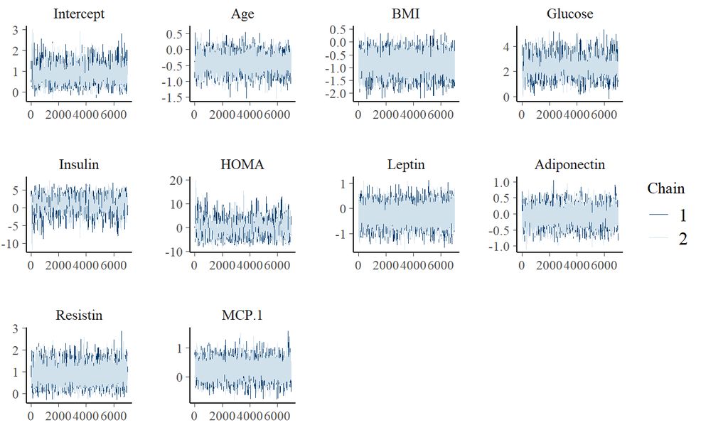

Trace Plot of HMC

Histograms of the posterior distribution show that certain variables such as HOMA are not normally distributed.

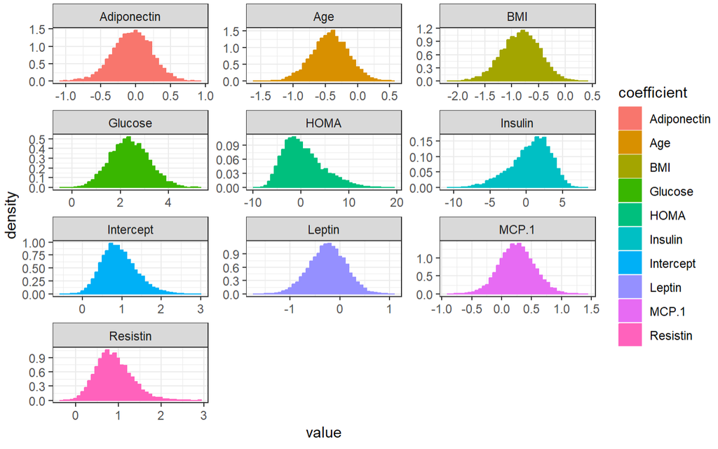

Density plot of HMC

The posterior quantiles are summarized after removing an initial burnin period. The $\hat R$ statistics provide an indication of convergence. Values close to one indicate that the multiple MCMC chains converged to the same distribution, while values above 1.1 indicate possible convergence problems. All the $\hat R$ statistics in our study are close to one.

#### 5.2.1.2 Frequentist-Logistic Regression

```r
data <- read.csv('dataR2.csv')
data$Classification <-ifelse(data$Classification == "1",0,1)

accuracy_list <- list()
auc_list <- list()
time_list <- list()
pred_prob_df <- data.frame(matrix(ncol = 0, nrow = 29))

for (i in c(1:20)) {
  set.seed(i)
  train <- sample(1:nrow(data),nrow(data)*3/4,replace = FALSE)
  Train <- data[train,]
  Test <- data[-train,]

  results_sim <- frequentist_logistic(Train,Test)

  accuracy_list[[i]] <- results_sim$accuracy
  auc_list[[i]] <-results_sim$AUC
  time_list[[i]] <- results_sim$time_cost

  pred_prob_df <- cbind(pred_prob_df, results_sim$prob)
}

accuracy_df <- t(data.frame(accuracy = unlist(accuracy_list)))
rownames(accuracy_df) <- "freq_accuracy"
colnames(accuracy_df) <- paste0("iteration_", 1:20)

auc_df <- t(data.frame(AUC = unlist(auc_list)))
rownames(auc_df) <- "freq_AUC"
colnames(auc_df) <- paste0("iteration_", 1:20)

time_df <- t(data.frame(time = unlist(time_list)))
rownames(time_df) <- "freq_time"
colnames(time_df) <- paste0("iteration_", 1:20)


colnames(pred_prob_df) <- paste0("iteration_", 1:20)

write.csv(pred_prob_df,"f_true_pred_prob_df.csv")
write.csv(time_df,"f_true_time_df.csv")
write.csv(auc_df,"f_true_auc_df.csv")
write.csv(accuracy_df,"f_true_accuracy_df.csv")
```

#### 5.2.1.3 Hierarchical Logistic Regression

```r
hierarchical_model <- function(Train,Test){
  stand_range <- preProcess(Train[,-10])
  Train_scaled <- cbind(predict(stand_range ,Train[,-10]),Train[,10]-1)
  Test_scaled <- cbind(predict(stand_range ,Test[,-10]), Test[,10]-1)
  t1 <- Sys.time()
  # model string
  jags.model = textConnection("model{
    for( i in 1:N) {
        xcent[i,1:9] <- x[i,1:9] - mean(x[,1:9])
    }
    for(i in 1:N){
        # likelihood:  y[i] ~ Bernoulli(p[i])
        y[i] ~ dbern(p[i])
        # the logit of p[i] is a linear function of the
        # centered log dose x[i]
        logit(p[i]) <- alpha.star + sum(xcent[i,] * beta) # Centered the covariate
    }
    alpha <- alpha.star - sum(t(mean(x[,1:9])) * beta)
    for(i in 1:9){
        beta[i] ~ dnorm(mu.beta, tau.beta)
    }

    alpha.star ~ dnorm(mu.alpha, tau.alpha)
    mu.beta ~ dnorm(0,0.000001)
    sigma.beta ~ dunif(1,10)
    tau.beta <- 1/(sigma.beta*sigma.beta)
    mu.alpha ~ dnorm(0,0.000001)
    sigma.alpha ~ dunif(20,30)
    tau.alpha <- 1/(sigma.alpha*sigma.alpha)
}")

  # train and MCMC

  data3 <- list(
    x = as.matrix(Train_scaled)[,-10],
    n = rep(1,dim(Train_scaled)[1]),
    y = as.vector(Train_scaled[,10]),
    N = dim(Train_scaled)[1])

  inits1 <- list(alpha.star=0, beta=rep(0.1, 9),mu.beta=0,mu.alpha=0,sigma.alpha=23,sigma.beta=3)
  inits2 <- list(alpha.star=0, beta=rep(-0.1, 9),mu.beta=0,mu.alpha=0,sigma.alpha=25,sigma.beta=5)
  inits3 <- list(alpha.star=0, beta=rep(0.7, 9),mu.beta=0,mu.alpha=0,sigma.alpha=28,sigma.beta=7)
  inits <- list(inits1,inits2,inits3)

  j.model <- jags.model(file = jags.model,
                        data = data3,
                        inits = inits,
                        n.chains = 3) # Set 3 chains
  update(j.model, 1000) # 1000 Update
  params <- c("alpha", "beta")
  jags.out <- coda.samples(j.model, params, n.iter = 50000, n.burnin = 2000)
  t2 <- Sys.time()
  # Set 50000 iterations

  # Calculate the accuracy in test data set
  res_all <- summary(jags.out)
  para.estimate <- res_all[1]$statistics[1:10,1]
  dim(para.estimate) <- c(10,1)
  prob <- as.matrix(cbind(1,Test_scaled[,-10]))%*%para.estimate
  prob1 <- exp(prob)/(1+exp(prob))
  auc <- roc(as.numeric(Test_scaled[,10]), prob1)$auc
  accu <- 1-sum(abs(as.numeric(prob1>0.5)-Test_scaled[,10]))/dim(Test_scaled)[1]

  return(list(res=jags.out,time=(t2-t1),accu=accu,auc=auc,pred_prob=prob1))
}

# res=hierarchical_model(Train,Test)
time_true <- c()
auc_true <- c()
accu_true <- c()
pred_prob_true=c()

for(i in 1:20){
  set.seed(i)
  train <- sample(1:nrow(data1),nrow(data1)*3/4,replace = FALSE)
  Train <- apply(data1[train,],2,as.numeric)
  Test <- apply(data1[-train,],2,as.numeric)
  res = hierarchical_model(Train,Test)
  time_true <- c(time_true,res$time)
  auc_true <- c(auc_true,res$auc)
  accu_true <- c(accu_true,res$accu)
  pred_prob_true <- cbind(pred_prob_true,res$pred_prob)

  cat("This is iteration",i)
}


write.csv(time_true,"time_true.csv")
write.csv(auc_true,"AUC_true.csv")
write.csv(accu_true,"Accuracy_true.csv")
write.csv(pred_prob_true,"Pred_prob_res_true.csv")
```

Trace plots provide a visual indication of stationarity. These plots indicate that the MCMC chains are reasonably stationary.

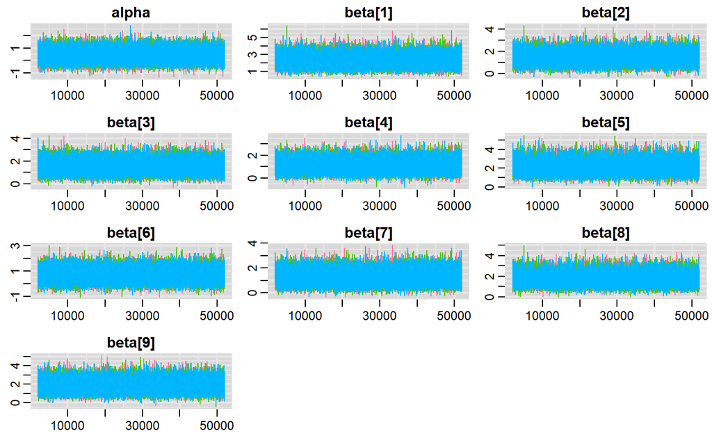

Trace plot of Hierarchical Method

[figure not shown]

Density Plot of Hierarchical Method

### 5.2.2 Naive Bayes

```r
#naive bayes function
naivebayes <- function(train_data,test_data){
  #train
  t1.lg <- Sys.time()#time
  nb_model <- naiveBayes(Classification ~ ., data = train_data)
  # predict
  predicted_probs <- predict(nb_model, newdata = test_data, type = "raw")
  predicted_class <- predict(nb_model, newdata = test_data, type = "class")

  t2.lg <- Sys.time()
  time_cost <- t2.lg - t1.lg

  # calculate auc

  roc_obj <- roc(test_data$Classification, predicted_probs[, "1"])
  auc <- auc(roc_obj)

  # calculate accuracy

  cft <- table(predicted_class,test_data$Classification)
  accu <- (cft[1,1]+cft[2,2])/nrow(test_data)

  return(list(prob = predicted_probs[,2] , accuracy = accu , AUC = auc , time_cost = time_cost , summary = nb_model))

}
```

```r
#iterations=20
data <- read.csv("dataR2.csv")

qual_vars <- c("Classification")
data[qual_vars] <- lapply(data[qual_vars], as.factor)


accuracy_list <- list()
auc_list <- list()
time_list <- list()
pred_prob_df_bn <- data.frame(matrix(ncol = 0, nrow = 29))

for (i in c(1:20)) {
  set.seed(i)
  train <- sample(1:nrow(data),nrow(data)*3/4,replace = FALSE)
  Train <- data[train,]
  Test <- data[-train,]

  stand_range <- preProcess(Train[,-10])
  Train_scaled <- cbind(predict(stand_range ,Train[,-10]),Train[,10])
  colnames(Train_scaled)[10] <- "Classification"
  Test_scaled <- cbind(predict(stand_range ,Test[,-10]), Test[,10])
  colnames(Test_scaled)[10] <- "Classification"


  nb <- naivebayes(Train_scaled,Test_scaled)
  accuracy_list[[i]] <- nb$accuracy
  auc_list[[i]] <- nb$AUC
  time_list[[i]] <- nb$time_cost

  #new_col <- t(nb$prob)
  pred_prob_df_bn <- cbind(pred_prob_df_bn, nb$prob)

}

accuracy_df_bn <- t(data.frame(accuracy = unlist(accuracy_list)))
rownames(accuracy_df_bn) <- "nb_accuracy"
colnames(accuracy_df_bn) <- paste0("iteration_", 1:20)
write.csv(accuracy_df_bn,"accuracy_df_bn.csv")


auc_df_bn <- t(data.frame(AUC = unlist(auc_list)))
rownames(auc_df_bn) <- "nb_AUC"
colnames(auc_df_bn) <- paste0("iteration_", 1:20)
write.csv(auc_df_bn,"auc_df_bn.csv")

time_df_bn <- t(data.frame(time = unlist(time_list)))
rownames(time_df_bn) <- "nb_time"
colnames(time_df_bn) <- paste0("iteration_", 1:20)
write.csv(time_df_bn,"time_df_bn.csv")

colnames(pred_prob_df_bn) <- paste0("iteration_", 1:20)
write.csv(pred_prob_df_bn,"pred_prob_df_bn.csv")
```

### 5.2.3 Decision Trees

```r
# Decision Trees function
tree <- function(train,test){
  a <- Sys.time()
  model <- rpart(Classification ~ ., data = train_data, method = "class")
  res <- summary(model)
  # prediction
  pred <- predict(model, newdata = test_data, type = "prob")

  pred_1 <- as.vector(pred[, 2])
  dim(pred_1) <- NULL
  #pred_1
  auc <- roc(as.numeric(test_data$Classification)-1, pred_1)$auc
  accu <- sum((pred_1>0.5)!=test[,10])/length(test[,1])
  b <- Sys.time()
  return(list(res=res,auc=auc,accu=accu,pred=pred_1,time=(b-a),model=model))

}
```

```r
accuracy_list <- list()
auc_list <- list()
time_list <- list()
pred_prob_df_trees <- data.frame(matrix(ncol = 0, nrow = 29))
for(i in 1:20){
  set.seed(seeds[i])
  train_idx <- sample(1:nrow(data1), 0.75 * nrow(data1))
  train_data <- data1[train_idx, ]
  test_data <- data1[-train_idx, ]

  stand_range <- preProcess(train_data[,-10])
  Train_scaled <- cbind(predict(stand_range ,train_data[,-10]),train_data[,10])
  colnames(Train_scaled)[10] <- "Classification"
  Test_scaled <- cbind(predict(stand_range ,test_data[,-10]), test_data[,10])
  colnames(Test_scaled)[10] <- "Classification"

  l1=tree(Train_scaled,Test_scaled)

  accuracy_list[[i]] <- l1$accu
  auc_list[[i]] <- l1$auc
  time_list[[i]] <- l1$time

  #new_col <- t(nb$prob)
  pred_prob_df_trees <- cbind(pred_prob_df_trees, l1$pred)


}

accuracy_df_trees <- t(data.frame(accuracy = unlist(accuracy_list)))
rownames(accuracy_df_trees) <- "trees_accuracy"
colnames(accuracy_df_trees) <- paste0("iteration_", 1:20)
write.csv(accuracy_df_trees,"accuracy_df_trees.csv")


auc_df_trees <- t(data.frame(AUC = unlist(auc_list)))
rownames(auc_df_trees) <- "nb_AUC"
colnames(auc_df_trees) <- paste0("iteration_", 1:20)
write.csv(auc_df_trees,"auc_df_trees.csv")

time_df_trees <- t(data.frame(time = unlist(time_list)))
rownames(time_df_trees) <- "trees_time"
colnames(time_df_trees) <- paste0("iteration_", 1:20)
write.csv(time_df_trees,"time_df_trees.csv")

colnames(pred_prob_df_trees) <- paste0("iteration_", 1:20)
write.csv(pred_prob_df_trees,"pred_prob_df_trees.csv")
```

## 5.3 Results

To select the top-performing models, we conduct 20 iterations of simulations and real data analysis to obtain accuracy, AUC, and runtime. We visualize the results using box plots, allowing for a more intuitive comparison.

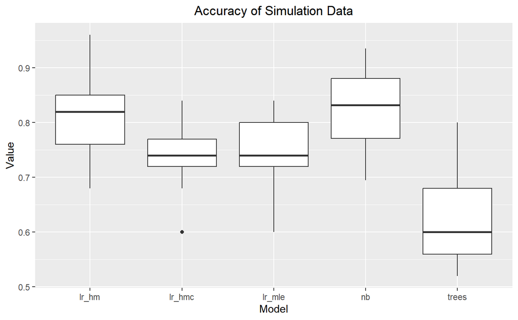

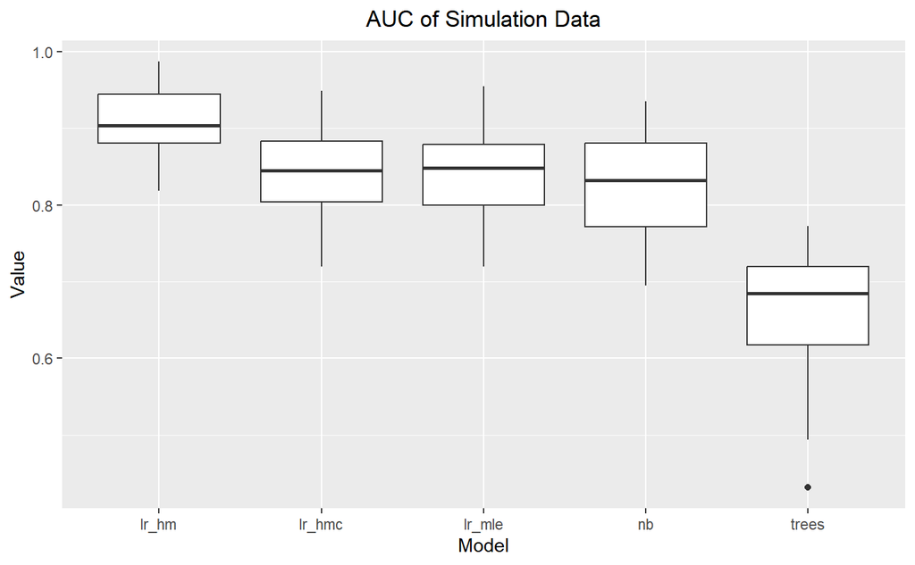

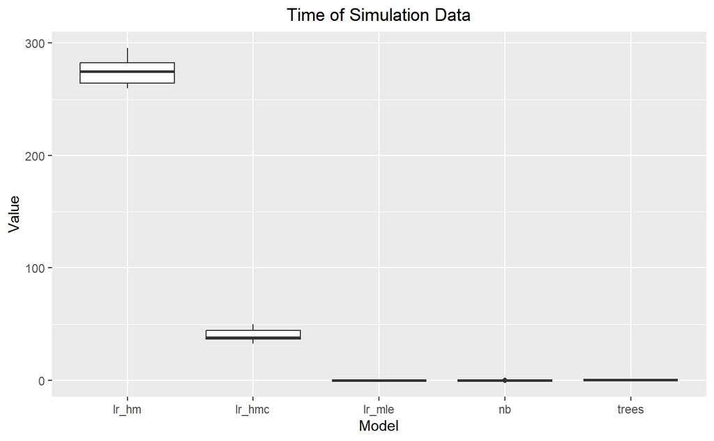

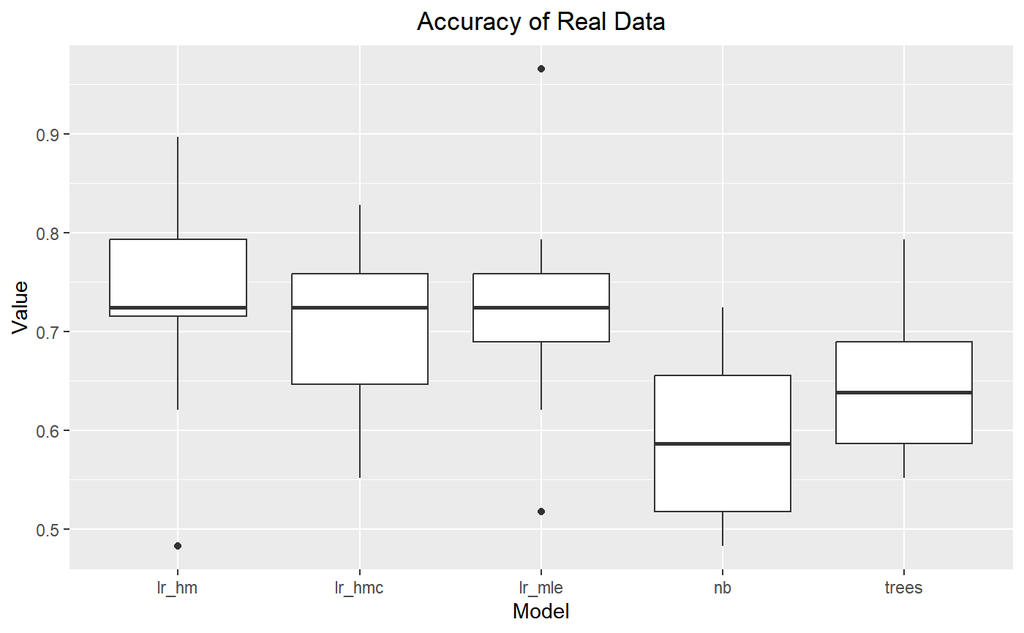

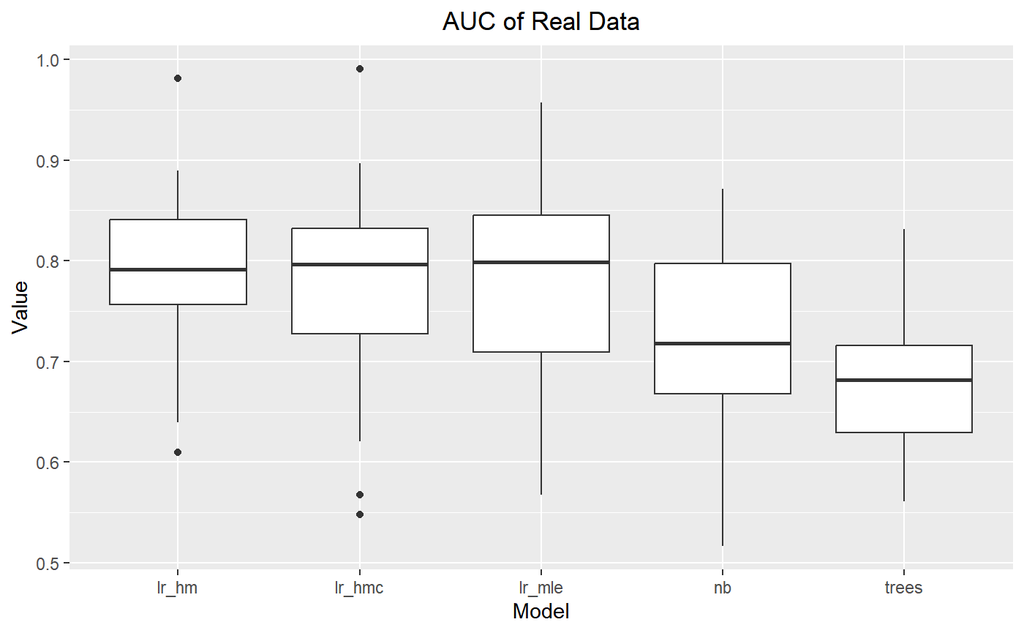

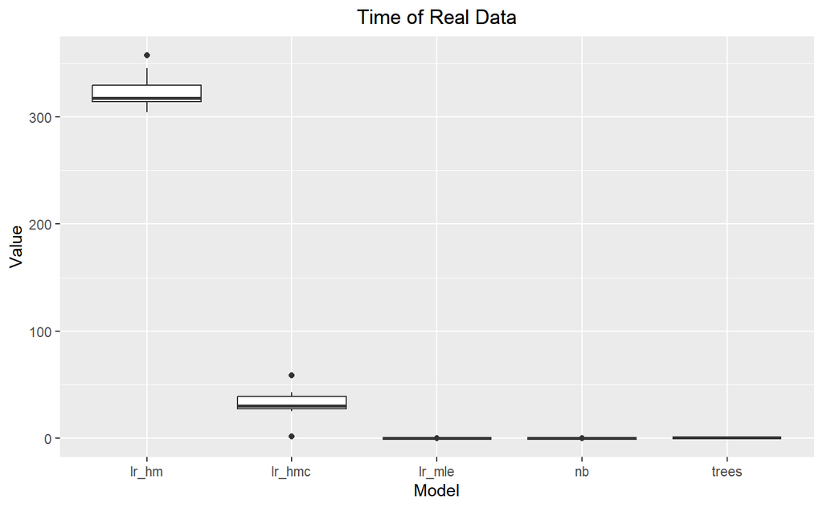

The code for generating box plots is as follows:

```r
accuracy_true <- read.csv("accuracy_true.csv")
auc_true <- read.csv("auc_true.csv")
time_true <- read.csv("time_true.csv")
accuracy_sim <- read.csv("accuracy_sim.csv")
auc_sim <- read.csv("auc_sim.csv")
time_sim <- read.csv("time_sim.csv")
```

```r
# real data
accuracy_long <- tidyr::gather(accuracy_true, key = "Model", value = "Value")

ggplot(accuracy_long, aes(x = Model, y = Value)) +
  geom_boxplot() +
  scale_color_lancet() + scale_fill_lancet() +
  labs(x = "Model", y = "Value") +
  ggtitle("Accuracy of Real Data")
```

```r
auc_long <- tidyr::gather(auc_true, key = "Model", value = "Value")


ggplot(auc_long, aes(x = Model, y = Value)) +
  geom_boxplot() +
  scale_color_lancet() + scale_fill_lancet() +
  labs(x = "Model", y = "Value") +
  ggtitle("AUC of Real Data")
```

```r
time_long <- tidyr::gather(time_true, key = "Model", value = "Value")

ggplot(time_long, aes(x = Model, y = Value)) +
  geom_boxplot() +
  scale_color_lancet() + scale_fill_lancet() +
  labs(x = "Model", y = "Value") +
  ggtitle("Time of Real Data")
```

```r
accuracy_long_sim <- tidyr::gather(accuracy_sim, key = "Model", value = "Value")

ggplot(accuracy_long_sim, aes(x = Model, y = Value)) +
  geom_boxplot() +
  scale_color_lancet() + scale_fill_lancet() +
  labs(x = "Model", y = "Value") +
  ggtitle("Accuracy of Simulation Data")
```

```r
auc_long_sim <- tidyr::gather(auc_sim, key = "Model", value = "Value")


ggplot(auc_long_sim, aes(x = Model, y = Value)) +
  geom_boxplot() +
  scale_color_lancet() + scale_fill_lancet() +
  labs(x = "Model", y = "Value") +
  ggtitle("AUC of Simulation Data")
```

```r
time_long_sim <- tidyr::gather(time_sim, key = "Model", value = "Value")


ggplot(time_long_sim, aes(x = Model, y = Value)) +
  geom_boxplot() +
  scale_color_lancet() + scale_fill_lancet() +
  labs(x = "Model", y = "Value") +
  ggtitle("Time of Simulation Data")
```

# 6 Explanation

## 6.1 Hierarchical Regression Model

However, it is worth noting that recent literature has shown some controversy regarding the impact of BMI and Glucose on the risk of breast cancer, which may explain the variations in interpretations across different models. Additionally, we observed that the regression coefficient for HOMA in the stratified model was not significantly different from zero, indicating the need for further investigation into its relationship with breast cancer risk.

## 6.2 Frequentist Logistic Regression

When modeling the logistic regression parameters using the maximum likelihood estimation (MLE) on the entire dataset, we find that the intercept term and the regression coefficient for Glucose were statistically significant. Additionally, the regression coefficients for BMI and HOMA were highly significant. It is worth noting that all coefficients, except for HOMA, were negative.

These results suggest that there is an inherent risk of breast cancer, and it is primarily influenced by the variables Glucose, BMI, and HOMA. Specifically, Glucose and BMI have a negative impact on the occurrence of breast cancer, while HOMA has a positive impact.

Therefore, the findings indicate that individuals with higher levels of Glucose and BMI may have a lower risk of developing breast cancer. On the other hand, higher levels of HOMA, which is a marker of insulin resistance, may contribute to an increased risk of breast cancer.

# 7 Conclusions

In order to enhance the prediction of breast cancer occurrence using statistical models, we select several individual models and evaluation metrics to assess the predictive performance based on a real dataset. We identify Hierarchical Logistic Regression and Frequentist Logistic Regression as the models that exhibit better predictive performance on this real dataset. Based on these two models, we explore the impact of predictor variables on the response variable in the dataset and find that Glucose, BMI, and HOMA are the primary influencers of the disease.

Also, we generate a simulation dataset to compare the prediction performance of different methods. On the simulation dataset, Hierarchical Logistic Regression and Naive Bayes demonstrated better overall performance. This finding contradicts the results obtained from the real dataset, suggesting that different methods are applicable to different datasets.

On the simulation dataset, we also compared the effectiveness of three parameter estimation methods and find that the Hierarchical Method displays the most advantageous parameter estimation results.

# 8 Discussions

The Hierarchical Method and MLE Method yield some differences in the significance results of parameter estimation. For instance, HOMA is not significant in the former but highly significant in the latter, which requires further investigation.

The selection of priors and parameter settings in the Hierarchical Method can be more flexible.

Naive Bayes performs poorly on the real dataset, potentially due to the violation of the independence assumption.

We attempted to use Bayesian networks, but our real dataset was not suitable for exploring causal relationships among the variables we selected.

# References

1. 王国才.朴素贝叶斯分类器的研究与应用[D].导师：张聪.重庆交通大学,2010
2. M. Patrício et al., “Using Resistin, glucose, age and BMI to predict the presence of breast cancer,” BMC Cancer, vol. 18, no. 1, pp. 1–8, 2018.
3. P. D. Hung, T. D. Hanh, and V. T. Diep, “Breast cancer prediction using spark MLlib and ML packages,” in Proceedings of the 2018 5th International Conference on Bioinformatics Research and Applications, 2018, pp. 52–59
4. A. G. Renehan et al, “Insulin-like growth factor (IGF)-I, IGF binding protein-3, and cancer risk: systematic review and meta-regression analysis,” The Lancet (British Edition), vol. 363, (9418), pp. 1346-1353, 2004.